# The Labyrinth of Multiple Testing: how to avoid the pitfall of false positives

The Labyrinth of Multiple Testing: how to avoid the pitfall of false positives FWER control Livio Finos

Suppose these are the p-values obtained from your last experiment:

```r
m=15
(p.values=runif(m))
```

```
##  [1] 0.45836403 0.86097027 0.59031924 0.06916149 0.51691009 0.65768056
##  [7] 0.79718389 0.29686948 0.80041971 0.24942859 0.76759684 0.54406981
## [13] 0.90205458 0.70099319 0.28480781
```

How many rejections?

```r
alpha = 0.05
(p.values < alpha)
```

```
##  [1] FALSE FALSE FALSE FALSE FALSE FALSE FALSE FALSE FALSE FALSE FALSE FALSE
## [13] FALSE FALSE FALSE
```

# 1 Familywise Error Rate

In hypothesis testing, the probability of committing a Type I error is controlled at a set level $\alpha$, conventionally 5%. However, a problem arises when we conduct not just one test, but more than one. Since for each test we have a probability of committing a type I error, if we conduct many tests it is likely to get at least one type I error.

The multiple testing problem has a simple structure. We have a set of null hypotheses $\mathcal{H}=(H_1,\ldots,H_m)$, of which an unknown number $m_0$ are true, while the remaining $m-m_0$ are false. We denote the subset of true hypotheses by $\mathcal{T}\subseteq \mathcal{H}$, the subset of false hypotheses by $\mathcal{F}=\mathcal{H}\setminus \mathcal{T}$ and the proportion of true hypotheses with $\pi_0=m_0/m$.

The goal of multiple verification procedures is to choose a subset $\mathcal{R}\subseteq \mathcal{H}$ of hypotheses to reject. Suppose we have available the p-values $p_1,\ldots,p_m$ for each hypothesis $H_1,\ldots,H_m$. We can consider the following procedure:
$$\mathcal{R}={H_i: p_i \leq \tilde{\alpha}$$
that is, reject all hypotheses whose p-values are less than some threshold $\tilde{\alpha}$. The problem now is to determine this threshold $\tilde{alpha}$.

Ideally, the set of rejected hypotheses $\mathcal{R}$ should coincide as closely as possible with the set of false hypotheses $\mathcal{F}$. Two types of errors can be made: type I errors $\mathcal{R}\cap \mathcal{T}$, that is, rejecting true hypotheses, and type II errors $\mathcal{R}\setminus \mathcal{F}$, that is, not rejecting false hypotheses.

We can summarize the number of errors made in the following table:

| Assumptions | True | False | Total |
| --- | --- | --- | --- |
| rejected | $V$ | $U$ | $R$ |
| not rejected | $m_0 - V$ | $m_1-U$ | $m-R$ |
| total | $m_0$ | $m_1$ | $m$ |

We know the total number of hypotheses $m$ and the number of rejected hypotheses $R=\#\mathcal{R}$, but all other table quantities are unknown. Methods of *multiple testing* try to reject as many hypotheses as possible while trying to control the number $V$ of type I errors.

The *familywise error rate* is defined as.
$$\mathrm{FWER}=\Pr(V > 0)$$
that is, the probability of committing at least one type I error. Using the procedure. * Rejection $H_i$ if $p_i \leq \tilde{\alpha}$

we get
$$\mathrm{FWER}= \Pr\left(\bigcup_{i: H_i \in \mathcal{T}} \{ P_i \leq
\tilde{\alpha} \right)$$

Controlling the *familywise error rate* at a $\alpha$ level requires that
$$\mathrm{FWER}\leq \alpha}$$

## 1.1 Sidak’s inequality: independent P-values.

In our example, we are in the following situation: * the $m=$ 15 hypotheses are all true, i.e. $m_0=m$; * the 15 tests, and thus the related p-values, are independent of each other; * without regard to the multiplicity of the tests, we reject $H_i$ when $p_i \leq \alpha$

We denote by $E_i=I\{P_i \leq \alpha}$ the outcome of the test, i.e., through the indicator function which is worth 1 if we reject the hypothesis, 0 otherwise. Since the hypotheses are all true, the p-values $P_1,\ldots,P_m$ are i.i.d. $\mathrm{Uniform}(0,1)$. It follows that $E_i \sim \mathrm{Bernoulli}(\alpha)$ and $V = \sum_{i=1}^{m}E_i \sim \mathrm{Binomial}(n,\alpha)$. Then the *familywise error rate* results in.
$$\mathrm{FWER}= \Pr(V > 0) = \Pr(\sum_{i=1}^{m}E_i > 0) = 1 -
\Pr(\sum_{i=1}^{m}E_i = 0) = 1 - (1-\alpha)^m$$
or equivalently
$$\mathrm{FWER}= \Pr\left(\bigcup_{i=1}^{m} \{ P_i \leq \alpha \} \right)
= 1- \Pr\left(\bigcap_{i=1}^{m} \{ P_i > \alpha \right) = 1-
\prod_{i=1}^{m} \Pr\left( P_i > \alpha \right) =1 - (1-\alpha)^m$$

that is, for $m=$ 15

```r
1 - (1-alpha)^(m)
```

```
## [1] 0.5367088
```

Let us try to represent the *familywise error rate* as a function of the number of the number of hypotheses $m$ (again assuming $m_0=m$)

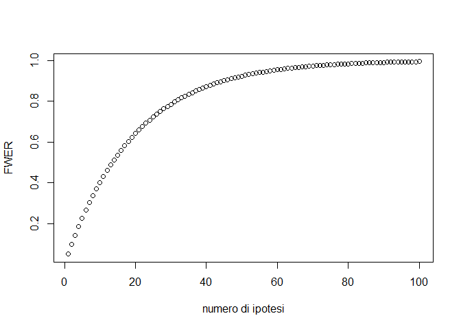

```r
# m = 100
FWER<- 1-(1-alpha)^(1:100)
plot(1:100,FWER,xlab="numero di ipotesi", ylab="FWER")
```

To control FWER at a $\alpha$ level, we need to modify our rejection rule:

- we reject $H_i$ when $p_i \leq \tilde{\alpha}$.

Solving $\mathrm{FWER}= 1 - (1-\tilde{\alpha})^m = \alpha$ we get
$$\tilde{\alpha} = 1-(1-\alpha)^{(1/m)}$$
or

```r
alpha.adj<-1 - (1-alpha)^(1/m)
alpha.adj
```

```
## [1] 0.003413713
```

```r
(p.values < alpha.adj)
```

```
##  [1] FALSE FALSE FALSE FALSE FALSE FALSE FALSE FALSE FALSE FALSE FALSE FALSE
## [13] FALSE FALSE FALSE
```

Equivalently, we can consider the rejection rule: * we reject the hypothesis $H_i$ when $\tilde{p}_{i} \leq \alpha$

where
$$\tilde{p}_i = 1- (1- p_i)^{m}$$
or

```r
p.values.adj<-1- (1- p.values)^m
p.values.adj
```

```
##  [1] 0.9998987 1.0000000 0.9999985 0.6587166 0.9999818 0.9999999 1.0000000
##  [8] 0.9949238 1.0000000 0.9864830 1.0000000 0.9999924 1.0000000 1.0000000
## [15] 0.9934485
```

More generally, if Sidak’s inequality holds:
$$\Pr\left(\bigcap_{i:H_i \in \mathcal{T}} \{ P_i > u \right) \geq
\prod_{i: H_i \in \mathcal{T}} \Pr\left( P_i > u \right)$$
for each $u\in[0,1]$ and each $\mathcal{T}\subseteq \mathcal{H}$, we can use $\tilde{\alpha} = 1-(1-\alpha)^{(1/m)}$ and obtain
$$\Pr\left(\bigcap_{i: H_i \in \mathcal{T}} \{ P_i >
1-(1-\alpha)^{(1/m)} \} \right) \geq \prod_{i: H_i\in \mathcal{T}}
\Pr\left( P_i > 1-(1-\alpha)^{(1/m)} \right) =
[(1-\alpha)^{(1/m)}]^{m_0} = (1-\alpha)^{pi_0} \geq 1-\alpha$$
And then check the FWER at $\alpha$:
$$\mathrm{FWER} = \Pr\left(\bigcup_{i: H_i \in \mathcal{T}} \{ P_i <
1-(1-\alpha)^{(1/m)} \} \right) = 1- \Pr\left(\bigcap_{i: H_i \in
\mathcal{T}} \{ P_i > 1-(1-\alpha)^{(1/m)} \} \right) \leq \alpha$$

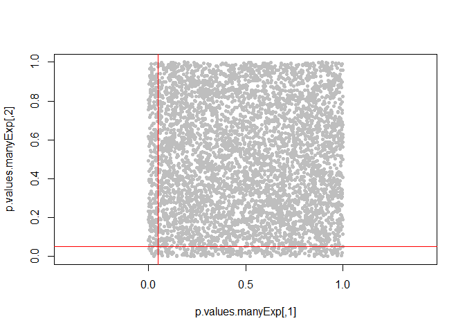

```r
p.values.manyExp=cbind(runif(5000),runif(5000))
plot(p.values.manyExp,pch=20,col="grey",asp=1)
abline(v=.05,col="red")
abline(h=.05,col="red")
```

Let’s try to run a simulation to verify that the FWER is really controlled at $\alpha$

```r
B<-5000
V<-vector("numeric", length=B)
for (i in 1:B){
U<-runif(m)
V[i]<-sum(U <= alpha.adj)
}
mean(V>0)
```

```
## [1] 0.0512
```

# 2 Bonferroni inequality

## 2.1 Dependence between tests.

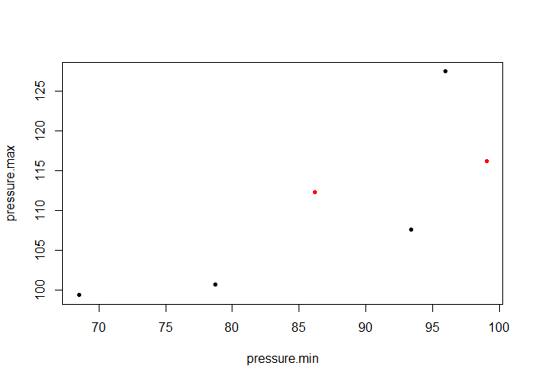

```r
effect.individual=rnorm(6,mean = 0,sd = sqrt(70))
pressure.min=rnorm(6,mean = 82,sd = sqrt(30))+effect.individual
pressure.max=rnorm(6,mean = 105,sd = sqrt(30))+effect.individual

plot(pressure.min,pressure.max,col=c("black", "black", "black", "red", "red"),pch=20)
```

```r
cor(pressure.min,pressure.max)
```

```
## [1] 0.7968978
```

```r
data=data.frame(drug=c("standard", "standard", "standard",
                        "new", "new", "new"),
                pressure.min=pressure.min,
                pressure.max=pressure.max)
data
```

| drug | pressure.min | pressure.max |
| --- | --- | --- |
| standard | 95.94601 | 127.48397 |
| standard | 93.41169 | 107.55898 |
| standard | 68.50253 | 99.35747 |
| new | 99.04417 | 116.24264 |
| new | 86.16865 | 112.26833 |
| new | 78.74107 | 100.69243 |

[figure not shown]

```r
B=5000
res=replicate(B,{
  effect.individual=rnorm(6,mean = 0,sd = sqrt(70))
  pressure.min=rnorm(6,mean = 82,sd = sqrt(30))+effect.individual
  pressure.max=rnorm(6,mean = 105,sd = sqrt(30))+effect.individual
  c(press.min=t.test(pressure.min[1:3],pressure.min[4:6])$p.value,
    press.max=t.test(pressure.max[1:3],pressure.max[4:6])$p.value)
})
res=t(res)
plot(res,pch=20,col="grey",asp=1)
abline(v=.05,col="red")
abline(h=.05,col="red")
```

```r
#with what probability both p-values<.05? (lower left area)
sum((res[,1]<.05)&(res[,2]<.05))/B
```

```
## [1] 0.007
```

```r
# how much is expected in case of test independence?
.05*.05
```

```
## [1] 0.0025
```

## 2.2 Carlo Emilio Bonferroni

Carlo Emilio Bonferroni was an Italian mathematician, best known for the inequalities that bear his name.

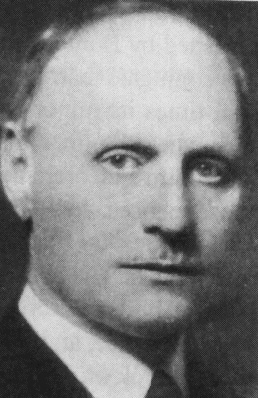

Bonferroni’s inequality, also known as Boole’s inequality, states that for any finite or countable collection of events, the probability of at least one of the events happening is less than or equal to the sum of the probabilities of the individual events, i.e.

$$\Pr\left(\bigcup_{i: H_i \in \mathcal{T}} E_i \right) \leq \sum_{i: H_i
\in \mathcal{T}} \Pr\left( E_i \right)$$

so considering $E_i = \P_i \leq \frac{alpha}{m} \}$ we get

$$\mathrm{FWER} = \Pr\left(\bigcup_{i: H_i \in \mathcal{T}} \P_i \leq
\frac{ \alpha}{m} \right) \leq \sum_{i: H_i \in \mathcal{T}} \Pr\left(
P_i \leq \frac{ \alpha}{m} \right) \leq m_0 \frac{ \alpha}{m} =
\pi_0\alpha \leq \alpha$$

that is, Bonferroni’s method controls the FWER at $\alpha$.

Bonferroni’s procedure is as follows:

- We reject $H_i$ if $p_i \leq \tilde{\alpha} = \frac{\alpha}{m}$

or equivalently.

- It rejects $H_i$ if $\tilde{p}_i = \min(mp_i,1) \leq \alpha$

## 2.3 Example: Multiple Endpoints Data

Let consider the `mtept` dataset:

```r
require("multcomp")
```

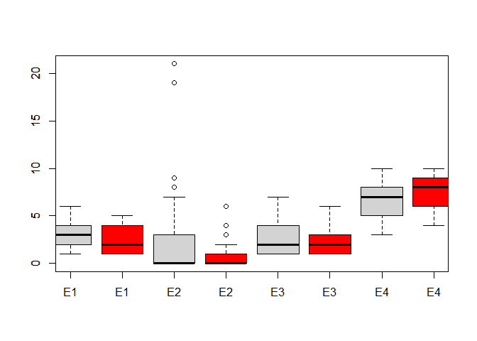

```r
data(mtept)
gruppo<-mtept[,"treatment"]
risposte<-mtept[,-1]
boxplot(risposte[gruppo=="Placebo",], at=c(1,3,5,7), xlim=c(1,8))
boxplot(risposte[gruppo=="Drug",], at=c(2,4,6,8), col="red", add=T)
```

We conduct 4 Wilcoxon tests, one for each endpoint:

```r
require("multcomp")
m<-4
p.values<-vector("numeric", length=m)
names(p.values)<-names(risposte)
for (i in 1:m){
p.values[i]<-wilcox.test(risposte[gruppo=="Placebo",i], risposte[gruppo=="Drug",i])$p.value
}
p.values
```

```
##        E1        E2        E3        E4
## 0.0187036 0.2500896 0.3237945 0.0257959
```

We now adjust the vector of p-values by Bonferroni’s method:

```r
p.values.adj<-pmin(p.values*m,1)
p.values.adj
```

```
##         E1         E2         E3         E4
## 0.07481439 1.00000000 1.00000000 0.10318359
```

```r
p.adjust(p.values,method="bonferroni")
```

```
##         E1         E2         E3         E4
## 0.07481439 1.00000000 1.00000000 0.10318359
```

```r
alpha = 0.1
names(p.values.adj)[p.values.adj<=alpha] # nomi degli endpoint significativi ad alpha=10%
```

```
## [1] "E1"
```

so the comparison between Placebo and Drug groups is significant at the $\alpha=10\%$ level for endpoint E1.

## 2.4 Example: Golub data

Let us now consider *microarray* type data used in the study described by Golub et al. (1999). In this study, gene expression on 3051 genes was measured for each patient. The 38 patients considered are leukemia patients, and can be divided into two groups: 27 patients with *acute lymphoblastic leukemia* (ALL) and with 11 *acute myeloid leukemia* (AML). The aim of the study is to determine which genes are differentially expressed between the two groups of patients.

```r
if (!require("BiocManager", quietly = TRUE))
    install.packages("BiocManager")
#BiocManager::install("multtest")

library(multtest)
set.seed(123)
data(golub)
rownames(golub)<-golub.gnames[,3]
m<-3051
geni<-1:m # sottoinsieme di geni
risposte<-golub[geni,]
gruppo<-golub.cl
p.values<-vector("numeric", length=m)
names(p.values)<-rownames(risposte)
for (i in 1:m){
p.values[i]<-t.test(risposte[i,gruppo==0], risposte[i,gruppo==1])$p.value
}
sum(p.values<=alpha) # numero di rifiuti senza correzione per molteplicità
```

```
## [1] 1334
```

```r
sum(p.adjust(p.values,"bonferroni") <=alpha) # numero di rifiuti con Bonferroni
```

```
## [1] 125
```

```r
p.values.adj <- p.adjust(p.values,"bonferroni")
geni.sig<-names(p.values.adj)[(p.values.adj <=alpha)] # nomi dei geni significativi
geni.sig
```

```
##   [1] "D14658_at"          "D14874_at"          "D21262_at"
##   [4] "D38524_at"          "D63476_at"          "D63880_at"
##   [7] "D86479_at"          "D86967_at"          "D87078_at"
##  [10] "D88270_at"          "D88422_at"          "HG1612-HT1612_at"
##  [13] "HG2855-HT2995_at"   "HG4582-HT4987_at"   "J05243_at"
##  [16] "L05148_at"          "L07758_at"          "L07956_at"
##  [19] "L08246_at"          "L20298_at"          "L28010_at"
##  [22] "L41870_at"          "L41887_rna1_at"     "L42572_at"
##  [25] "L47738_at"          "M11147_at"          "M11722_at"
##  [28] "M13792_at"          "M16038_at"          "M21551_rna1_at"
##  [31] "M22960_at"          "M23197_at"          "M27891_at"
##  [34] "M29536_at"          "M29696_at"          "M33680_at"
##  [37] "M55150_at"          "M60527_at"          "M62762_at"
##  [40] "M63138_at"          "M69043_at"          "M77142_at"
##  [43] "M83233_at"          "M89957_at"          "M91432_at"
```

[output cut: 27 more lines]

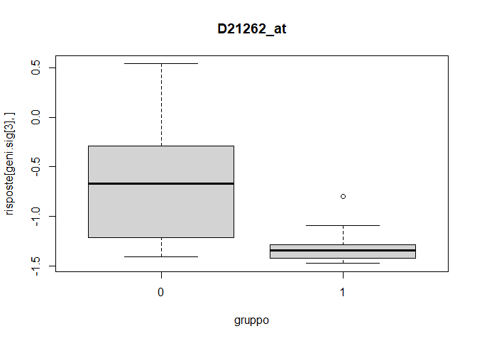

```r
boxplot(risposte[geni.sig[3],]~gruppo, main=geni.sig[3]) # boxplot del terzo gene significativo
```

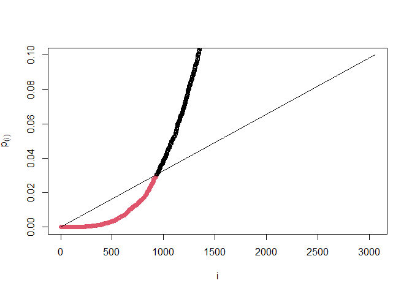

```r
i<-(sort(p.values) <= alpha*(1:m)/m)
plot(1:m, sort(p.values), xlab="i", ylab=expression(p[(i)]), col=i+1, ylim=c(0,.1))
segments(x0=1,y0=alpha/m, x1=m,y1=alpha)
```

# 3 Holm procedure

It leads to the same waste as Bonferroni, sometimes a few more (uniformly more powerful).

It is iterative:

1. Correct the p-values with Bonferroni,
2. Reject all hypotheses with significant p-value
3. Reiterate 1. and 2. until there are no more rejections

```r
p.values
```

[output not shown]

[output cut: 2997 more lines]

[output not shown]

```r
p.adjust(p.values,method = "bonferroni")
```

[output not shown]

[output cut: 2997 more lines]

[output not shown]

```r
p.adjust(p.values,method = "holm")
```

[output not shown]

[output cut: 2997 more lines]

[output not shown]